# Wiki scraping et ggplot: Population des Etats-Unis et Recensement

Hurgland-Nick KELIET

## R Markdown

### Importation des librairies

```r
# Webscrapper
library(rvest)
# Télécharger des données depuis un site
library(tidyverse)
```

```r
# Visualisation
library(ggplot2)

# Cartographie
library(maps)
# palette de couleur
require(viridis)
```

### Récupération de la page wikipédia

```r
page_wiki = read_html('https://en.wikipedia.org/wiki/List_of_U.S._states_and_territories_by_population')
```

### Récupération du tableau intitulé: “State rankings”

```r
# Nous savons que nous voulons récupérer une table
liste_etats <- page_wiki %>% html_nodes("table") %>% html_table(fill = TRUE)
```

**Nous pouvons voir que sur R console : [[1]] [[2]] [[3]] [[4]] [[5]] mais aussi hors console que le tableau est illisible**

*Ces numéros indiquent le nombre de tableau dans la page et le tableau que nous voulons est le 1er*

### Récupération de notre tableau “State rankings”

```r
liste_etats <- page_wiki %>% html_nodes("table") %>% .[[1]] %>% html_table(fill = TRUE)
head(liste_etats)
```

```
##      Rank Rank        State         Census population Census population
## 1 Current Rank         2010 Estimate, July 1, 2019[8] Census population
## 2       1    1   California                39,512,223        37,253,956
## 3       2    2        Texas                28,995,881        25,145,561
## 4       3    4      Florida                21,477,737        18,801,310
## 5       4    3     New York                19,453,561        19,378,102
## 6       5    6 Pennsylvania                12,801,989        12,702,379
##   Change, 2010–2019 Change, 2010–2019
## 1 Change, 2010–2019  April 1, 2010[9]
## 2              6.1%        +2,257,700
## 3             15.3%        +3,850,320
## 4             14.2%        +2,676,427
## 5              0.4%           +75,459
## 6              0.8%           +99,610
##   Total U.S. House of Representatives Seats
```

[output cut: 27 more lines]

**Maintenant Nous voyons que les données sont désormais un peu lisibles, ce que nous cherchions 😋** *Mais nous avons une erreur, la première ligne que nous devons supprimer et les noms des colonnes que nous devons mettre dans les normes*

### changer les noms des colonnes

```r
names(liste_etats) <- make.names(names(liste_etats))
head(liste_etats)
```

```
##      Rank Rank        State         Census.population Census.population
## 1 Current Rank         2010 Estimate, July 1, 2019[8] Census population
## 2       1    1   California                39,512,223        37,253,956
## 3       2    2        Texas                28,995,881        25,145,561
## 4       3    4      Florida                21,477,737        18,801,310
## 5       4    3     New York                19,453,561        19,378,102
## 6       5    6 Pennsylvania                12,801,989        12,702,379
##   Change..2010.2019 Change..2010.2019
## 1 Change, 2010–2019  April 1, 2010[9]
## 2              6.1%        +2,257,700
## 3             15.3%        +3,850,320
## 4             14.2%        +2,676,427
## 5              0.4%           +75,459
## 6              0.8%           +99,610
##   Total.U.S..House.of.Representatives.Seats
```

[output cut: 27 more lines]

*Nous avons préparer le nom des colonnes pour les lier à la map sans problème*

### Vérifions le type des variables pour voir s’il n y a point d’erreurs

```r
str(liste_etats)
```

```
## 'data.frame':    61 obs. of  12 variables:
##  $ Rank                                                 : chr  "Current" "1" "2" "3" ...
##  $ Rank                                                 : chr  "Rank" "1" "2" "4" ...
##  $ State                                                : chr  "2010" "California" "Texas" "Florida" ...
##  $ Census.population                                    : chr  "Estimate, July 1, 2019[8]" "39,512,223" "28,995,881" "21,477,737" ...
##  $ Census.population                                    : chr  "Census population" "37,253,956" "25,145,561" "18,801,310" ...
##  $ Change..2010.2019                                    : chr  "Change, 2010–2019" "6.1%" "15.3%" "14.2%" ...
##  $ Change..2010.2019                                    : chr  "April 1, 2010[9]" "+2,257,700" "+3,850,320" "+2,676,427" ...
##  $ Total.U.S..House.of.Representatives.Seats            : chr  "Total U.S. House of Representatives Seats" "53" "36" "27" ...
##  $ Estimated.population.per.electoral.vote..2019.note.1.: chr  "Percent[note 3]" "718,404" "763,050" "740,611" ...
##  $ Census.population.per.House.seat                     : chr  "Absolute" "745,514" "805,441" "795,472" ...
##  $ Census.population.per.House.seat                     : chr  "Estimated, 2019" "702,885" "698,503" "696,468" ...
##  $ Percent.of.the.total.U.S..population..2019.note.2.   : chr  "2010" "11.91%" "8.74%" "6.47%" ...
```

**Nous voyons d’après ce qui précède, que il y a des erreurs sur le type des colonnes** *Essayons de réparer tout ce désordre*

### Retirons la première lignes

```r
liste_etats <- liste_etats[-1,]
head(liste_etats)
```

```
##   Rank Rank        State Census.population Census.population
## 2    1    1   California        39,512,223        37,253,956
## 3    2    2        Texas        28,995,881        25,145,561
## 4    3    4      Florida        21,477,737        18,801,310
## 5    4    3     New York        19,453,561        19,378,102
## 6    5    6 Pennsylvania        12,801,989        12,702,379
## 7    6    5     Illinois        12,671,821        12,830,632
##   Change..2010.2019 Change..2010.2019
## 2              6.1%        +2,257,700
## 3             15.3%        +3,850,320
## 4             14.2%        +2,676,427
## 5              0.4%           +75,459
## 6              0.8%           +99,610
## 7             –1.2%          –158,811
##   Total.U.S..House.of.Representatives.Seats
```

[output cut: 27 more lines]

### Retirons les virgules dans les colonnes qui nous intéressent grâce aux expressions régulières.

```r
for(i in 4:11)
liste_etats[i] = gsub(",","",liste_etats[,i])
head(liste_etats)
```

```
##   Rank Rank        State Census.population Census.population
## 2    1    1   California          39512223          37253956
## 3    2    2        Texas          28995881          25145561
## 4    3    4      Florida          21477737          18801310
## 5    4    3     New York          19453561          19378102
## 6    5    6 Pennsylvania          12801989          12702379
## 7    6    5     Illinois          12671821          12830632
##   Change..2010.2019 Change..2010.2019
## 2              6.1%          +2257700
## 3             15.3%          +3850320
## 4             14.2%          +2676427
## 5              0.4%            +75459
## 6              0.8%            +99610
## 7             –1.2%           –158811
##   Total.U.S..House.of.Representatives.Seats
```

[output cut: 27 more lines]

```r
str(liste_etats)
```

```
## 'data.frame':    60 obs. of  12 variables:
##  $ Rank                                                 : chr  "1" "2" "3" "4" ...
##  $ Rank                                                 : chr  "1" "2" "4" "3" ...
##  $ State                                                : chr  "California" "Texas" "Florida" "New York" ...
##  $ Census.population                                    : chr  "39512223" "28995881" "21477737" "19453561" ...
##  $ Census.population                                    : chr  "37253956" "25145561" "18801310" "19378102" ...
##  $ Change..2010.2019                                    : chr  "6.1%" "15.3%" "14.2%" "0.4%" ...
##  $ Change..2010.2019                                    : chr  "+2257700" "+3850320" "+2676427" "+75459" ...
##  $ Total.U.S..House.of.Representatives.Seats            : chr  "53" "36" "27" "27" ...
##  $ Estimated.population.per.electoral.vote..2019.note.1.: chr  "718404" "763050" "740611" "670812" ...
##  $ Census.population.per.House.seat                     : chr  "745514" "805441" "795472" "720502" ...
##  $ Census.population.per.House.seat                     : chr  "702885" "698503" "696468" "717707" ...
##  $ Percent.of.the.total.U.S..population..2019.note.2.   : chr  "11.91%" "8.74%" "6.47%" "5.86%" ...
```

**Super ce que nous avons déja réalisé**

```r
names(liste_etats)
```

```
##  [1] "Rank"
##  [2] "Rank"
##  [3] "State"
##  [4] "Census.population"
##  [5] "Census.population"
##  [6] "Change..2010.2019"
##  [7] "Change..2010.2019"
##  [8] "Total.U.S..House.of.Representatives.Seats"
##  [9] "Estimated.population.per.electoral.vote..2019.note.1."
## [10] "Census.population.per.House.seat"
## [11] "Census.population.per.House.seat"
## [12] "Percent.of.the.total.U.S..population..2019.note.2."
```

#2) Carte intégré à la librairie Map de R.

```r
# Carte
carte_USA <- map_data("state")

# Variable de notre map
str(carte_USA)
```

```
## 'data.frame':    15537 obs. of  6 variables:
##  $ long     : num  -87.5 -87.5 -87.5 -87.5 -87.6 ...
##  $ lat      : num  30.4 30.4 30.4 30.3 30.3 ...
##  $ group    : num  1 1 1 1 1 1 1 1 1 1 ...
##  $ order    : int  1 2 3 4 5 6 7 8 9 10 ...
##  $ region   : chr  "alabama" "alabama" "alabama" "alabama" ...
##  $ subregion: chr  NA NA NA NA ...
```

### Créons une nouvelle colonne nommée “région” et ayant tout les noms des régions en minuscules.

```r
# En minuscule
liste_etats$region <- tolower(liste_etats$State)

# Vérification des colonnes et type de notre dataset
str(liste_etats)
```

```
## 'data.frame':    60 obs. of  13 variables:
##  $ Rank                                                 : chr  "1" "2" "3" "4" ...
##  $ Rank                                                 : chr  "1" "2" "4" "3" ...
##  $ State                                                : chr  "California" "Texas" "Florida" "New York" ...
##  $ Census.population                                    : chr  "39512223" "28995881" "21477737" "19453561" ...
##  $ Census.population                                    : chr  "37253956" "25145561" "18801310" "19378102" ...
##  $ Change..2010.2019                                    : chr  "6.1%" "15.3%" "14.2%" "0.4%" ...
##  $ Change..2010.2019                                    : chr  "+2257700" "+3850320" "+2676427" "+75459" ...
##  $ Total.U.S..House.of.Representatives.Seats            : chr  "53" "36" "27" "27" ...
##  $ Estimated.population.per.electoral.vote..2019.note.1.: chr  "718404" "763050" "740611" "670812" ...
##  $ Census.population.per.House.seat                     : chr  "745514" "805441" "795472" "720502" ...
##  $ Census.population.per.House.seat                     : chr  "702885" "698503" "696468" "717707" ...
##  $ Percent.of.the.total.U.S..population..2019.note.2.   : chr  "11.91%" "8.74%" "6.47%" "5.86%" ...
##  $ region                                               : chr  "california" "texas" "florida" "new york" ...
```

**Job done**

### restaurons les types des colonnes qui devraient être numérique.

```r
# Sélectionnons les colonnes
colonnes <- c(4,5,7,9,10,11)

# Loop
for(i in colonnes){
  liste_etats[,i] <- as.numeric(liste_etats[,i])
}
# Vérifications
str(liste_etats)
```

```
## 'data.frame':    60 obs. of  13 variables:
##  $ Rank                                                 : chr  "1" "2" "3" "4" ...
##  $ Rank                                                 : chr  "1" "2" "4" "3" ...
##  $ State                                                : chr  "California" "Texas" "Florida" "New York" ...
##  $ Census.population                                    : num  39512223 28995881 21477737 19453561 12801989 ...
##  $ Census.population                                    : num  37253956 25145561 18801310 19378102 12702379 ...
##  $ Change..2010.2019                                    : chr  "6.1%" "15.3%" "14.2%" "0.4%" ...
##  $ Change..2010.2019                                    : num  2257700 3850320 2676427 75459 99610 ...
##  $ Total.U.S..House.of.Representatives.Seats            : chr  "53" "36" "27" "27" ...
##  $ Estimated.population.per.electoral.vote..2019.note.1.: num  718404 763050 740611 670812 640099 ...
##  $ Census.population.per.House.seat                     : num  745514 805441 795472 720502 711222 ...
##  $ Census.population.per.House.seat                     : num  702885 698503 696468 717707 705715 ...
##  $ Percent.of.the.total.U.S..population..2019.note.2.   : chr  "11.91%" "8.74%" "6.47%" "5.86%" ...
##  $ region                                               : chr  "california" "texas" "florida" "new york" ...
```

**Job Done car on peut maintenant voir des colonnes en numérique**

```r
names(liste_etats)
```

```
##  [1] "Rank"
##  [2] "Rank"
##  [3] "State"
##  [4] "Census.population"
##  [5] "Census.population"
##  [6] "Change..2010.2019"
##  [7] "Change..2010.2019"
##  [8] "Total.U.S..House.of.Representatives.Seats"
##  [9] "Estimated.population.per.electoral.vote..2019.note.1."
## [10] "Census.population.per.House.seat"
## [11] "Census.population.per.House.seat"
## [12] "Percent.of.the.total.U.S..population..2019.note.2."
## [13] "region"
```

### Croisons les données

*map 1*

[output not shown]

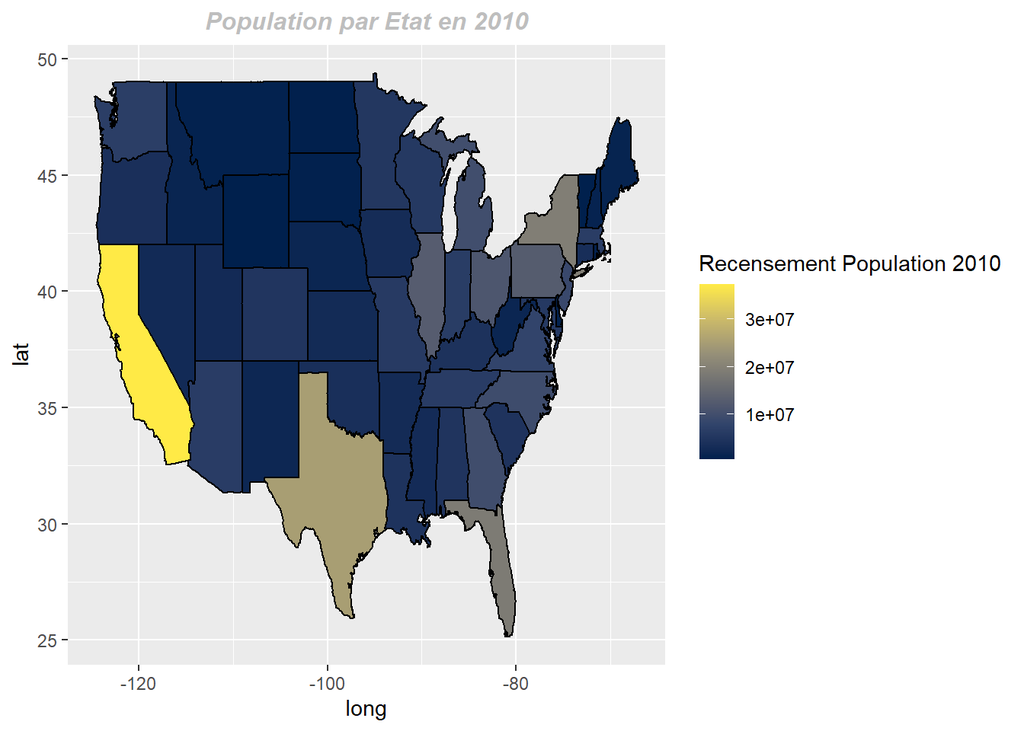

```r
if (require("maps")) {

# Effectuons la jointure des données entre df_prediction et les données de la map state
df_Map_complet <- merge(carte_USA, liste_etats, by = "region", all.x = TRUE)

# Organiser les données
df_Map_complet <- df_Map_complet[order(df_Map_complet$group), ]

# ggplot
# map 1 : Population en 2010
ggplot(df_Map_complet, aes(x = long, y = lat, group = group, fill = Census.population.1)) +
geom_polygon(color = "black") +
scale_fill_gradient(low = "white", high = "red", guide = "legend", na.value = "white") +
labs(fill = "Recensement Population 2010") +
ggtitle("Population par Etat en 2010") +
theme(plot.title = element_text(color = "grey", size = 12, face = "bold.italic", hjust = 0.5)) +
  scale_fill_viridis_c(option = "E")
}
```

*map 2*

[output not shown]

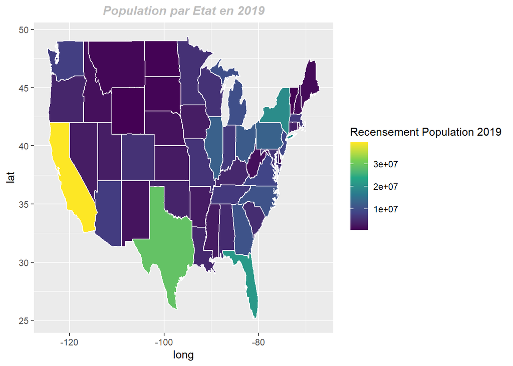

```r
if (require("maps")) {
# map 2 : Population en 2019
ggplot(df_Map_complet, aes(x = long, y = lat, group = group, fill = Census.population)) +
geom_polygon(color = "white") +
scale_fill_gradient(low = "skyblue", high = "Orange", guide = "legend", na.value = "white") +
labs(fill = "Recensement Population 2019") +
ggtitle("Population par Etat en 2019") +
theme(plot.title = element_text(color = "grey", size = 12, face = "bold.italic", hjust = 0.5)) +
scale_fill_viridis_c(option = "D")
}
```

*map 3*

[output not shown]

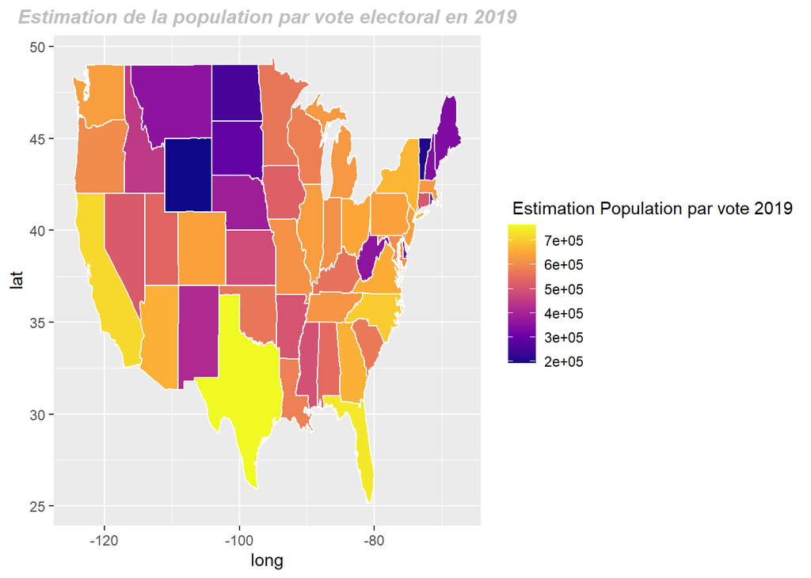

```r
if (require("maps")){
# map 2 : Population en 2019
ggplot(df_Map_complet, aes(x = long, y = lat, group = group, fill = Estimated.population.per.electoral.vote..2019.note.1.)) +
geom_polygon(color = "white") +
scale_fill_gradient(low = "white", high = "red", guide = "legend", na.value = "white") +
labs(fill = " Estimation Population par vote 2019") +
ggtitle("Estimation de la population par vote electoral en 2019") +
theme(plot.title = element_text(color = "grey", size = 12, face = "bold.italic", hjust = 0.5)) +
scale_fill_viridis_c(option = "C")
}
```